### **Trial design interface in action**

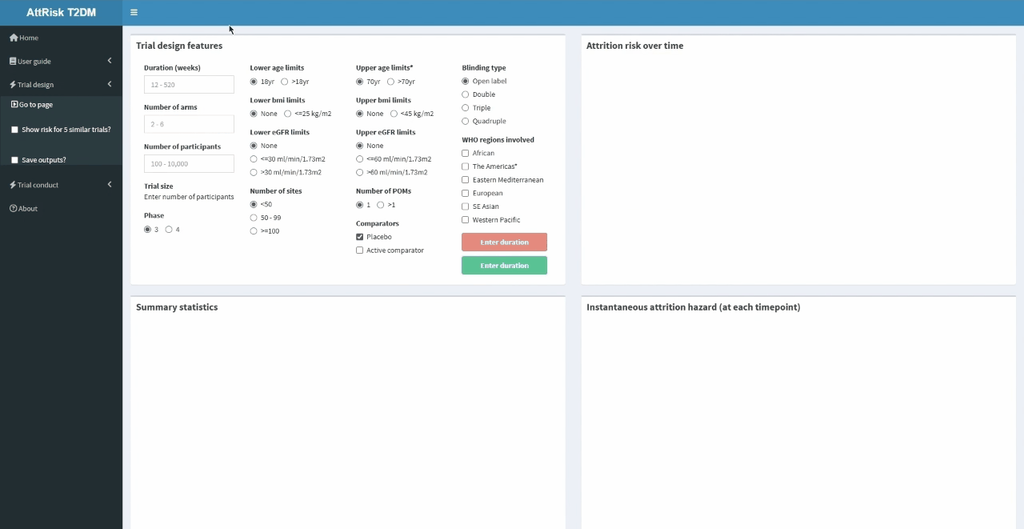

The interface has the following features:

- **Box A (top-left)** - Trial design features
- **Box B (top-right)** - Attrition risk over time
- **Box C (bottom-left)** - Summary statistics
- **Box D (bottom-right)** - Instantaneous attrition hazard (at each timepoint)

### **Trial design features**

**Box A** displays the inputs for trial design features. Most features have a default value set upon opening the interface, but these can be changed by selecting the other available options for a feature.

Features with an astrix beside the name indicate a significant predictor of attrition risk.

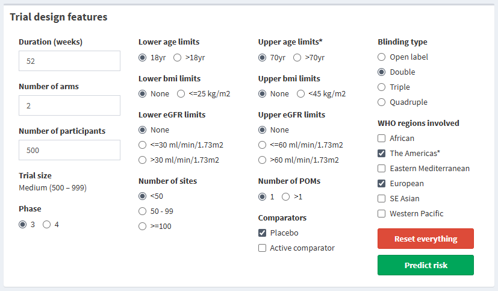

The available set of trial design inputs are:

| Features | Description | Categories and limits |
| --- | --- | --- |
| Duration | Duration of trial follow-up in weeks | 12 to 520 weeks |
| Number of arms | Number of treatment arms | 2 to 6 arms |
| Number of participants | Total number of randomised participants | 100 to 10,000 randomised participants |
| Trial size | Trial size (based on inputed total number of participants) | Based on number of participants: Small (<500), Medium (500 - 999), Large (>=1000) |
| Age limits | Upper and lower age limits | Upper: 70yr, >70yrs; Lower: 18yrs, >18yrs |
| BMI limits | Upper and lower BMI limits | Upper: None, <45kg/m2; Lower: None, <=25kg/m2 |
| eGFR limits | Upper and lower estimated glomerular filtration rate (eGFR) limits | Upper: None, <=60 or >60ml/min/1.73m2; Lower: None, <=30 or >30ml/min/1.73m2 |
| Phase | Trial phase | Phase 3 or 4 |
| Number of primary outcomes (POMs) | Number of primary outcomes | 1 or >1 |
| Comparators | Comparator treatment groups | Placebo, Active comparator or both |
| Blinding type | Level of blinding | Open label, Double, Triple or Quadruple |
| WHO regions involved | World Health Organisation (WHO) regions involved | Can select more than one of the following: African, the Americas, Eastern Mediterranean, Europe, South-east Asia, Western Pacific |

### **Attrition risk over time**

**Box B** illustrates the risk of attrition over time. This provides an overview of how likely attrition is to occur by a particular timepoint (e.g. week 26, week 52).

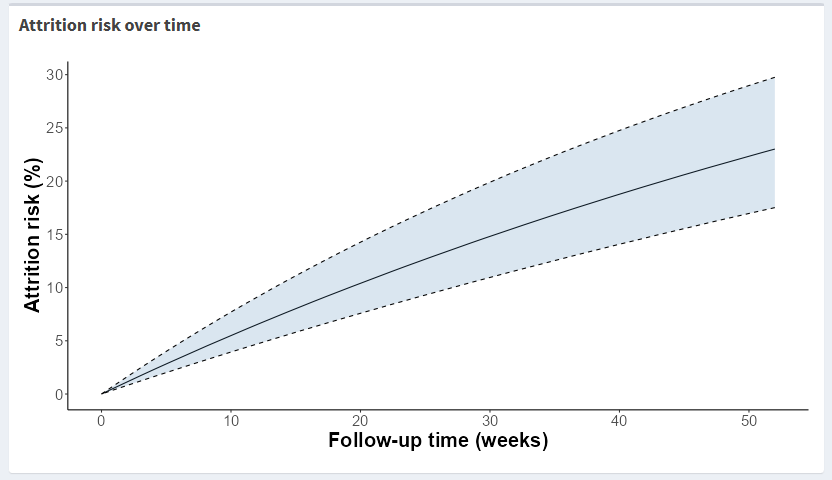

The timeframe reflects the duration inputted in **Box A**. The y-axis illustrates risk of attrition (%), and the x-axis illustrates follow-up time in weeks.

### **Summary statistics**

**Box C** displays summary statistics for attrition risk over time.

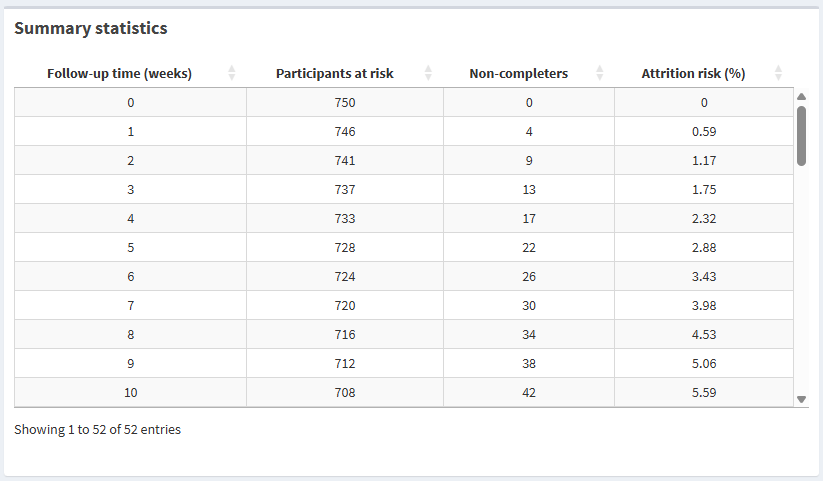

The following columns are generated in this summary table:

| Columns | Description |
| --- | --- |
| Follow-up time (weeks) | Each week of follow-up |
| Participants at risk | Number of participants at risk of attrition at a given week |
| Non-completers | Number of non-completers at a given week |
| Attrition risk (%) | The probability of attrition having occurred at a given week |

### **Instantaneous attrition hazard (at each timepoint)**

**Box D** illustrates the rate of attrition at each timepoint. This gives an idea of when attrition is most likely to occur during a trial (e.g. is it more likely at the start or the end of follow-up).

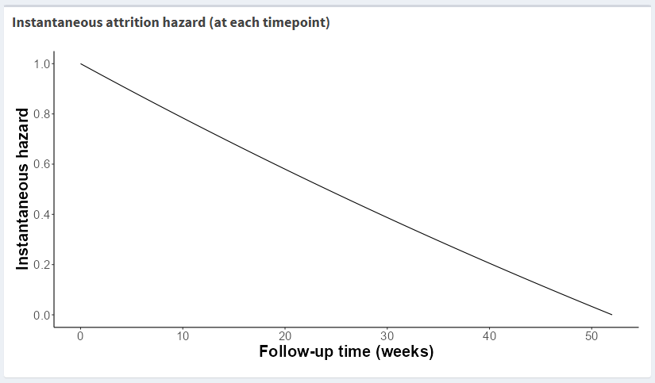

The timeframe is setup the same as **Box B**. The y-axis represents a scaled hazard rate, ranging from 0 (lowest) to 1 (highest).